# Capstone_project

Author : Joy

Last Updated : 2022-09-02

## Project Overview

This whole project is based on a bike sharing company , where we will analyze 12 months riding data set in order to answer some business questions and to provide some recommendations based on our analysis.

## The Scenario

Cyclistic launched a bike sharing service at Chicago in 2016. Since then, the program has grown to a fleet of 5,824 bicycles that are geotracked and locked into a network of 692 stations across Chicago. Customers who purchase single-ride or full-day passes are referred to as casual riders. Customers who purchase annual memberships are Cyclistic members. Our stakeholder concluded that annual members are much more profitable than casual riders.Although the pricing flexibility helps Cyclistic attract more customers, our stakeholder believes that maximizing the number of annual members will be key to future growth. rather then creating marketing campeins to attract new customers , our stakeholder belives that maximizing annual members will be key to future growth.

## Business Taks

**How can we convert “Casual” riders to annual “Members”**

## Steps

We will follow the steps what we’ve learned so far .

The **Steps are** :

- Ask
- Prepare
- Process
- Analyze
- Share
- Act

### Since we’ve completed **“Ask”** phase by knowing who is our stakeholder and what questions we have to answer, We will continue from our **“Prepare Phase”**

## Prepare

In this phase we will know about our data.

Then we’ll import the data from source.

After import we will organize those data sets in order to keep everything concise and readable.

#### Download the data from [here](https://divvy-tripdata.s3.amazonaws.com/index.html)

#### After download

- First create a seperate folder for only this project.
- Name the folder .
- Move downloaded data sets to the Folder.
- Rename data sets to identify clearly

#### **Since we have to work with 12 months data sets which are separated in 12 csv files**

#### We will combine those 12 data sets into **“One” Data Frame!**

But first we need to import them

##### First we need to install required package to read our csv files.

`install.packages('tidyverse')`

##### After installing the package we will load it up.

```r
library(tidyverse)  #Loading the package using library function.
```

**Tidyverse** is the most popular package to work with data related field . It comes with lots of functionality.

##### Now we will read those csv files using `read_csv`function included in “Tidyverse” package.

##### Reading a csv file

```r
csv_data = read_csv("/Users/joy/Desktop/data_analysis/case_study_1_data/202207-divvy-tripdata.csv") # Read csv
```

##### Since we have 12 csv files , we are going to read them as list items to combine them easily.

```r
datas = list(read_csv("/Users/joy/Desktop/data_analysis/case_study_1_data/202207-divvy-tripdata.csv"),
         read_csv("/Users/joy/Desktop/data_analysis/case_study_1_data/202206-divvy-tripdata.csv"),
         read_csv("/Users/joy/Desktop/data_analysis/case_study_1_data/202205-divvy-tripdata.csv"),
         read_csv("/Users/joy/Desktop/data_analysis/case_study_1_data/202204-divvy-tripdata.csv"),
         read_csv("/Users/joy/Desktop/data_analysis/case_study_1_data/202203-divvy-tripdata.csv"),
         read_csv("/Users/joy/Desktop/data_analysis/case_study_1_data/202202-divvy-tripdata.csv"),
         read_csv("/Users/joy/Desktop/data_analysis/case_study_1_data/202201-divvy-tripdata.csv"),
         read_csv("/Users/joy/Desktop/data_analysis/case_study_1_data/202112-divvy-tripdata.csv"),
         read_csv("/Users/joy/Desktop/data_analysis/case_study_1_data/202111-divvy-tripdata.csv"),
         read_csv("/Users/joy/Desktop/data_analysis/case_study_1_data/202110-divvy-tripdata.csv"),
         read_csv("/Users/joy/Desktop/data_analysis/case_study_1_data/202109-divvy-tripdata.csv"),
         read_csv("/Users/joy/Desktop/data_analysis/case_study_1_data/202108-divvy-tripdata.csv")
)
```

##### Now we will combine this 12 csv files into one using `bind_rows` included with “Tidyverse”

```r
combined_df = bind_rows(datas) # Combining all csv files into one data frame
```

#### That’s it we are almost done with our **“Prepare”** phase . We have organized our data. Now we will start our **“Process”** part.

## Process

In this phase of our data analysis we will clean our data and will add some new fields to work with Analyze part.

#### Now we will add `distance traveled` column to calculate how much a rider has traveled in one trip

To use distHaversine for calculation, first we need to install and load package called `geosphere`

```r
 install.packages('geosphere')
```

```r
library(geosphere) # loading geosphere package
```

**Now we can add our new column**

```r
cleaned_data = combined_df %>%
  mutate(distance_traveled = distHaversine(cbind(start_lng, start_lat), cbind(end_lng, end_lat)))
```

#### Haversine is a formula which calculates distance from one location to another location using longitude and latitude.

#### Notice that we are using a symbol `%>%` . This symbol enable us to combine multiple statements on a single block, which is pretty handy.

#### We can check if the column was added or not using `colnames(data_frame)` function

```r
colnames(cleaned_data)
```

```
##  [1] "ride_id"            "rideable_type"      "started_at"
##  [4] "ended_at"           "start_station_name" "start_station_id"
##  [7] "end_station_name"   "end_station_id"     "start_lat"
## [10] "start_lng"          "end_lat"            "end_lng"
## [13] "member_casual"      "distance_traveled"
```

*New column was added successfully*

#### Now let’s check if there is any negative value in our new column, we will sort the data by distance traveled

```r
head(select(arrange(cleaned_data, distance_traveled), distance_traveled), n=10)
```

```
## # A tibble: 10 × 1
##    distance_traveled
##                <dbl>
##  1                 0
##  2                 0
##  3                 0
##  4                 0
##  5                 0
##  6                 0
##  7                 0
##  8                 0
##  9                 0
## 10                 0
```

#### There is no negative values but we can see lot of 0 values , which indicates wrong data.

#### Hence we will filter them out for our analysis.

#### We can use filter function for this task

```r
filter(distance_traveled > 0) # filtering by distance traveled  > 0
```

In code

```r
cleaned_data = combined_df %>%
  mutate(distance_traveled = distHaversine(cbind(start_lng, start_lat), cbind(end_lng, end_lat))) %>%
  filter(distance_traveled > 0)
```

#### Now we’ll check again for value with 0

```r
head(select(arrange(cleaned_data, distance_traveled), distance_traveled), n=10)
```

```
## # A tibble: 10 × 1
##    distance_traveled
##                <dbl>
##  1            0.0231
##  2            0.0332
##  3            0.0333
##  4            0.0333
##  5            0.0333
##  6            0.0368
##  7            0.0396
##  8            0.0401
##  9            0.0408
## 10            0.0414
```

#### There we go. We’ve filtered values with 0.

#### Now that we know the distance traveled by a rider. We are also interested in figuring out how much time it took to complete a travel

#### For this we will `subtract` ended_at with started_at using `difftime` base function.

Example

```r
  duration_in_min = as.double(difftime(ended_at, started_at, units = 'mins'))
```

#### We will calculate duration in minutes , using piping for this task

```r
cleaned_data = combined_df %>%
  mutate(distance_traveled = distHaversine(cbind(start_lng, start_lat), cbind(end_lng, end_lat))) %>%
  filter(distance_traveled > 0) %>% # filtering distance traveled
  mutate(duration_in_min = as.double(difftime(ended_at, started_at, units = 'mins'))) # calculating and adding duration_in_min column into data frame
```

#### Now let us check if there is any wrong data. Which shouldn’t be there

```r
head(select(arrange(cleaned_data, duration_in_min), duration_in_min), n=10)
```

```
## # A tibble: 10 × 1
##    duration_in_min
##              <dbl>
##  1          -130.
##  2          -129.
##  3          -126.
##  4          -126.
##  5          -117.
##  6          -101.
##  7           -58.0
##  8           -55.9
##  9           -54.1
## 10           -53.8
```

#### It seems that we have lot of wrong `date data` which is not right. We will filter this negative values too.

#### We will use filter function again for this task

```r
filter(duration_in_min > 0) # filtering by duration in min  > 0
```

In code

```r
cleaned_data = combined_df %>%
  mutate(distance_traveled = distHaversine(cbind(start_lng, start_lat), cbind(end_lng, end_lat))) %>%
  filter(distance_traveled > 0) %>%
  mutate(duration_in_min = as.double(difftime(ended_at, started_at, units = 'mins'))) %>%
  filter(duration_in_min>0)  # Filtering data frame if duration in min has a negetive value
```

#### Now let us check again if there’s still any wrong data

```r
head(select(arrange(cleaned_data, duration_in_min), duration_in_min), n=10)
```

```
## # A tibble: 10 × 1
##    duration_in_min
##              <dbl>
##  1          0.0167
##  2          0.0167
##  3          0.0167
##  4          0.0167
##  5          0.0167
##  6          0.0167
##  7          0.0167
##  8          0.0167
##  9          0.0167
## 10          0.0167
```

#### **Great we’ve removed wrong data.**

#### Since our data set is too large there is a chance that lot of `Null values` will be in it

Let’s check how many Null values are in our data set

```r
sum(is.na(cleaned_data))
```

```
## [1] 3054590
```

Looks like we have tons of missing values. Although we will take care of this values later , but for now fill them with ‘missing_value’

#### To fill out we will use `replace(is.na(dataframe), 'missing_value')`

In code

```r
cleaned_data = combined_df %>%
  mutate(distance_traveled = distHaversine(cbind(start_lng, start_lat), cbind(end_lng, end_lat))) %>%
  filter(distance_traveled > 0) %>%
  mutate(duration_in_min = as.double(difftime(ended_at, started_at, units = 'mins'))) %>%
  filter(duration_in_min>0) %>%
  replace(is.na(.), 'missing_value') # Replacing null values with missing_value parameter
```

#### Now that we have a cleaned dataframe we’re ready to analyze it. Before starting analyze we will arrange the whole data frame by starting date in ascending order

```r
cleaned_data = combined_df %>%
  mutate(distance_traveled = distHaversine(cbind(start_lng, start_lat), cbind(end_lng, end_lat))) %>%
  filter(distance_traveled > 0) %>%
  mutate(duration_in_min = as.double(difftime(ended_at, started_at, units = 'mins'))) %>%
  filter(duration_in_min>0) %>%
  replace(is.na(.), 'missing_value') %>%
  arrange(started_at) # Arranging data by starting date in ascending order
```

#### According to our starting date , we need another column containing weekday name for further analysis

Adding `day_of_week` column to data frame according to starting date

```r
cleaned_data$day_of_week <- weekdays(as.Date(cleaned_data$started_at))
cleaned_data$day_of_week <- factor(cleaned_data$day_of_week, levels=c('Saturday','Sunday', 'Monday', 'Tuesday', 'Wednesday', 'Thursday', 'Friday'))
```

#### Now let’s take a sneak peek to our current data

```r
head(cleaned_data, n=10)
```

```
## # A tibble: 10 × 16
##    ride_id       ridea…¹ started_at          ended_at            start…² start…³
##    <chr>         <chr>   <dttm>              <dttm>              <chr>   <chr>
##  1 D6AC43863387… classi… 2021-08-01 00:00:04 2021-08-01 00:13:28 Clark … TA1305…
##  2 00015E7CD37F… classi… 2021-08-01 00:00:17 2021-08-01 00:05:10 Racine… TA1306…
##  3 3B9554C39413… classi… 2021-08-01 00:00:19 2021-08-01 00:05:54 Wells … TA1306…
##  4 3F35D7C35A1D… classi… 2021-08-01 00:00:27 2021-08-01 00:12:17 Halste… 13192
##  5 A39DD0D9AD71… classi… 2021-08-01 00:00:32 2021-08-01 00:12:06 Broadw… 13325
##  6 46C654999C4B… classi… 2021-08-01 00:00:37 2021-08-01 00:21:03 Wells … KA1504…
##  7 0D6C68A027BA… classi… 2021-08-01 00:00:38 2021-08-01 00:18:06 Califo… 15642
##  8 105738879E10… electr… 2021-08-01 00:00:47 2021-08-01 00:06:34 missin… missin…
##  9 61DB513996B2… electr… 2021-08-01 00:00:47 2021-08-01 00:14:00 Halste… TA1309…
## 10 03D890D86770… electr… 2021-08-01 00:00:55 2021-08-01 00:24:34 Sherid… RP-009
## # … with 10 more variables: end_station_name <chr>, end_station_id <chr>,
## #   start_lat <dbl>, start_lng <dbl>, end_lat <dbl>, end_lng <dbl>,
## #   member_casual <chr>, distance_traveled <dbl>, duration_in_min <dbl>,
## #   day_of_week <fct>, and abbreviated variable names ¹rideable_type,
## #   ²start_station_name, ³start_station_id
## # ℹ Use `colnames()` to see all variable names
```

### Heads up, we are ready for our **“Analyze”** part

## Analyze

In this part of analysis we will discover and find some key findings to answer our business question and to provide recommendations.

**We will use ggplot2 for our basic visualization**

#### First we will check out weekly frequency distributions.

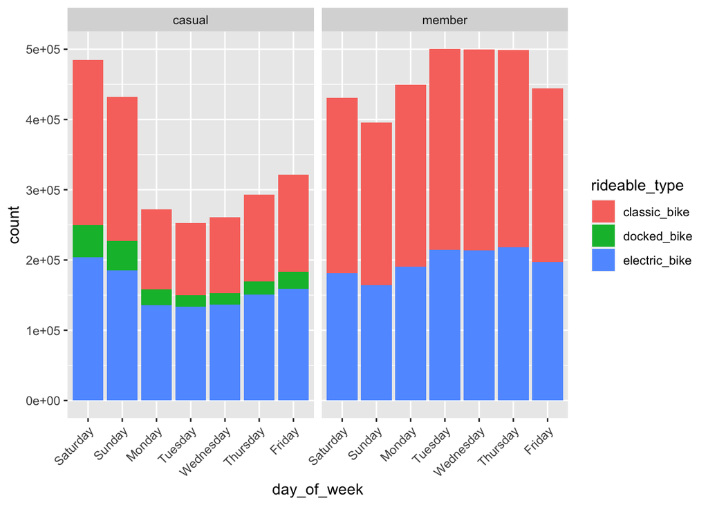

#### From this visualization we can observe some key points

- Members bike usage are quite similar throughout the week except Sunday , which bit slower. Which means most of the members are worker or employees
- For Casual riders, whole week frequency is bit slower except Saturday and Sunday , from this we can say that casual riders usage increases during weekends.
- Members likes using classic and electric bikes most same as Casual riders.
- Members are not interested in using docket bike

#### Let’s check out duration frequency too using histogram chart

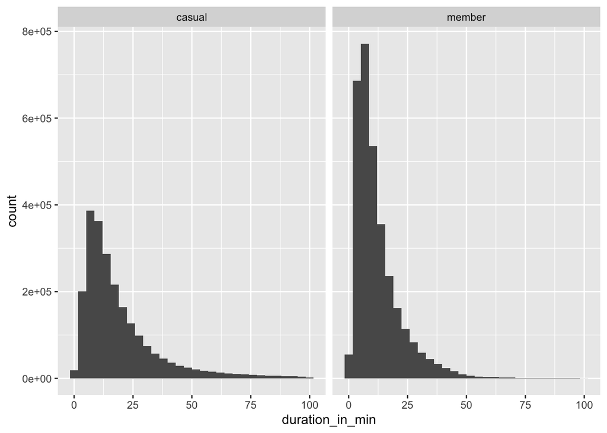

#### We can see members tends to take shorter trip than Casual riders. Or casuals take longer trips than members. We will talk about the mean trip duration later using summary

#### Now lets check distance traveled by meters in density chart

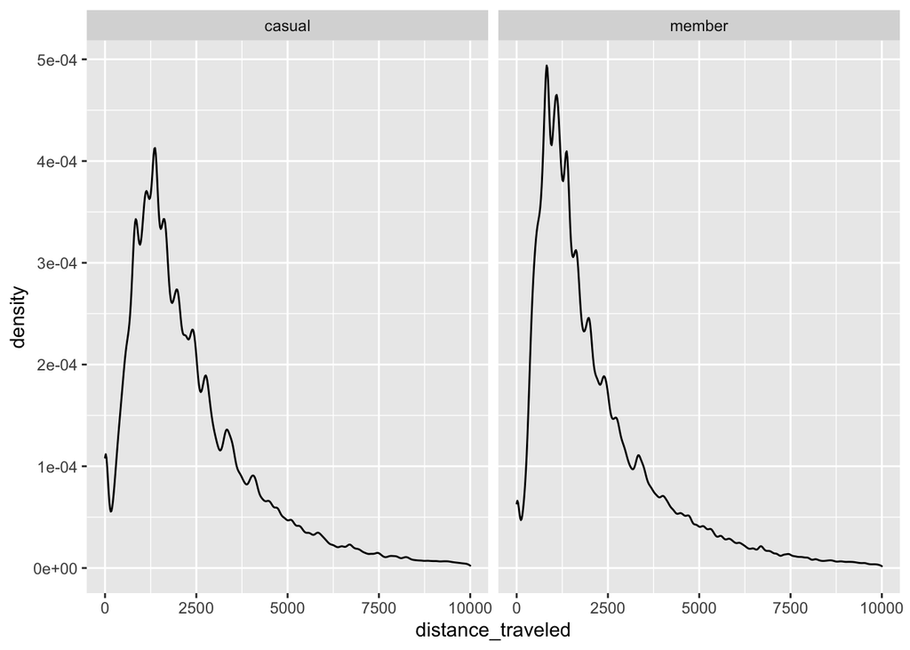

#### It’s pretty hard to observe anything from this charts, instead we will summarize the data.

#### Before summarizing we will divide member and casual separately

```r
members = filter(cleaned_data, cleaned_data$member_casual == 'member')
casual = filter(cleaned_data, cleaned_data$member_casual == 'casual')
```

#### Summary data of distance traveled , and duration traveled

```r
# member summary


summary(drop_na(select(members, c('day_of_week', 'distance_traveled', 'duration_in_min'))))
```

```
##     day_of_week     distance_traveled  duration_in_min
##  Saturday :430925   Min.   :    0.02   Min.   :   0.0167
##  Sunday   :395848   1st Qu.:  950.91   1st Qu.:   5.4333
##  Monday   :449590   Median : 1587.75   Median :   9.1500
##  Tuesday  :500336   Mean   : 2195.85   Mean   :  12.7033
##  Wednesday:499598   3rd Qu.: 2807.91   3rd Qu.:  15.6500
##  Thursday :499180   Max.   :42319.46   Max.   :1499.9333
##  Friday   :444595
```

```r
# casual summary

summary(drop_na(select(casual, c('day_of_week', 'distance_traveled', 'duration_in_min'))))
```

```
##     day_of_week     distance_traveled duration_in_min
##  Saturday :484975   Min.   :      0   Min.   :    0.02
##  Sunday   :432557   1st Qu.:   1141   1st Qu.:    8.40
##  Monday   :272322   Median :   1891   Median :   14.23
##  Tuesday  :252547   Mean   :   2455   Mean   :   23.62
##  Wednesday:260604   3rd Qu.:   3162   3rd Qu.:   25.12
##  Thursday :292844   Max.   :1190854   Max.   :41629.17
##  Friday   :321754
```

#### Now we will find out which are most popular start and end stations for Casual and Annual Members.

Member popular start stations

```r
head(count(members, start_station_name, sort=T), n=10) # Start station count
```

```
## # A tibble: 10 × 2
##    start_station_name                n
##    <chr>                         <int>
##  1 missing_value                418019
##  2 Kingsbury St & Kinzie St      26040
##  3 Wells St & Concord Ln         23028
##  4 Clark St & Elm St             22937
##  5 Wells St & Elm St             20298
##  6 Ellis Ave & 60th St           19557
##  7 Clinton St & Washington Blvd  19235
##  8 Clinton St & Madison St       19216
##  9 University Ave & 57th St      19001
## 10 Dearborn St & Erie St         18301
```

Member popular end stations

```r
head(count(members, end_station_name, sort=T), n=10) # End station count
```

```
## # A tibble: 10 × 2
##    end_station_name                  n
##    <chr>                         <int>
##  1 missing_value                414925
##  2 Kingsbury St & Kinzie St      25741
##  3 Wells St & Concord Ln         23727
##  4 Clark St & Elm St             23290
##  5 Wells St & Elm St             20332
##  6 Clinton St & Washington Blvd  20059
##  7 Clinton St & Madison St       19781
##  8 University Ave & 57th St      19728
##  9 Ellis Ave & 60th St           19066
## 10 Dearborn St & Erie St         18576
```

Casual popular start stations

```r
head(count(casual, start_station_name, sort=T), n=10) # Start station count
```

```
## # A tibble: 10 × 2
##    start_station_name                      n
##    <chr>                               <int>
##  1 missing_value                      319482
##  2 Streeter Dr & Grand Ave             53806
##  3 DuSable Lake Shore Dr & Monroe St   27777
##  4 Millennium Park                     25586
##  5 DuSable Lake Shore Dr & North Blvd  24966
##  6 Michigan Ave & Oak St               24128
##  7 Shedd Aquarium                      19761
##  8 Wells St & Concord Ln               18375
##  9 Theater on the Lake                 18316
## 10 Wells St & Elm St                   14910
```

Casual popular end stations

```r
head(count(casual, end_station_name, sort=T), n=10) # End station count
```

```
## # A tibble: 10 × 2
##    end_station_name                        n
##    <chr>                               <int>
##  1 missing_value                      374870
##  2 Streeter Dr & Grand Ave             55878
##  3 DuSable Lake Shore Dr & North Blvd  28733
##  4 Millennium Park                     26627
##  5 Michigan Ave & Oak St               25528
##  6 DuSable Lake Shore Dr & Monroe St   25427
##  7 Theater on the Lake                 19402
##  8 Shedd Aquarium                      18618
##  9 Wells St & Concord Ln               17601
## 10 Clark St & Lincoln Ave              14643
```

#### From above summary we can see that members most used start and are same . And casual most used start and end stations are also same too.

#### We have to concatenate start station with end stations to find out most populart starting and ending point

Members

```r
# member
members$route = paste(members$start_station_name, ' ------ ', members$end_station_name)
head(count(members, route, sort=T), n=10)
```

```
## # A tibble: 10 × 2
##    route                                                      n
##    <chr>                                                  <int>
##  1 missing_value  ------  missing_value                  209407
##  2 Ellis Ave & 60th St  ------  Ellis Ave & 55th St        5667
##  3 Ellis Ave & 60th St  ------  University Ave & 57th St   5646
##  4 University Ave & 57th St  ------  Ellis Ave & 60th St   5485
##  5 Ellis Ave & 55th St  ------  Ellis Ave & 60th St        4983
##  6 University Ave & 57th St  ------  missing_value         2955
##  7 Ellis Ave & 60th St  ------  missing_value              2645
##  8 missing_value  ------  University Ave & 57th St         2501
##  9 Calumet Ave & 33rd St  ------  State St & 33rd St       2494
## 10 missing_value  ------  Ellis Ave & 60th St              2407
```

Casual Riders

```r
# casual
casual$route = paste(casual$start_station_name, ' ------ ', casual$end_station_name)
head(count(casual, route, sort=T), n=10)
```

```
## # A tibble: 10 × 2
##    route                                                                    n
##    <chr>                                                                <int>
##  1 missing_value  ------  missing_value                                177697
##  2 DuSable Lake Shore Dr & Monroe St  ------  Streeter Dr & Grand Ave    5463
##  3 Streeter Dr & Grand Ave  ------  Millennium Park                      3052
##  4 Streeter Dr & Grand Ave  ------  DuSable Lake Shore Dr & Monroe St    2921
##  5 Millennium Park  ------  Streeter Dr & Grand Ave                      2740
##  6 Shedd Aquarium  ------  Streeter Dr & Grand Ave                       2686
##  7 Streeter Dr & Grand Ave  ------  Michigan Ave & Oak St                2484
##  8 Streeter Dr & Grand Ave  ------  missing_value                        2467
##  9 Streeter Dr & Grand Ave  ------  DuSable Lake Shore Dr & North Blvd   2394
## 10 Streeter Dr & Grand Ave  ------  Streeter Dr & Grand Ave              2105
```

#### Now we will summarize our Analysis key points using `date.frame` function from `formattable` package

First we need install and load `formattable` package.

```r
install.packages("formattable")
```

```r
library(formattable) # loading package
```

It was kind a boring to type out these raw , but the output wroth it

| User.Type | Amount | Avg_and_median_trip_dur | Avg_and_median_trip_distance | Busiest.Day | Preferred.bike.type | Most.occaurd.route |
| --- | --- | --- | --- | --- | --- | --- |
| Member | 3220072 (58.14%) | 12.70 min - 9.15 min | 2195.85 meters - 1587.75 meters | Tuesday | classic & electric | Ellis Ave & 60th St -Ellis Ave & 55th St (5667) |
| Casual | 2317603 (41.86%) | 23.62 min - 14.23 min | 2455 meters - 1891 meters | Saturday | electric | DuSable Lake Shore Dr & Monroe St - Streeter Dr & Grand Ave (5463) |

#### Now will try to figure out why there is so many missing values in the date

```r
missing_data = drop_na(filter(cleaned_data, start_station_name=='missing_value')) # Filtering missing values
summary(select(missing_data, c('day_of_week', 'distance_traveled', 'duration_in_min'))) # Summarizing missing values
```

```
##     day_of_week     distance_traveled  duration_in_min
##  Saturday :117623   Min.   :   10.56   Min.   :  0.0167
##  Sunday   :107009   1st Qu.: 1113.19   1st Qu.:  6.1167
##  Monday   : 96016   Median : 1995.56   Median : 10.5167
##  Tuesday  : 99942   Mean   : 2674.73   Mean   : 14.9585
##  Wednesday:101040   3rd Qu.: 3441.19   3rd Qu.: 18.4833
##  Thursday :108259   Max.   :30725.77   Max.   :480.5167
##  Friday   :107612
```

#### Checking which bike type data is missing most

```r
head(count(missing_data , member_casual, rideable_type, sor=T), n=10)
```

```
## # A tibble: 2 × 4
##   member_casual rideable_type sor        n
##   <chr>         <chr>         <lgl>  <int>
## 1 casual        electric_bike TRUE  319482
## 2 member        electric_bike TRUE  418019
```

#### We can see that electric bikes datas are only missing.

#### Let’s see how much electric bike data is in the dataset

```r
count(filter(cleaned_data, rideable_type=='electric_bike'))
```

```
## # A tibble: 1 × 1
##         n
##     <int>
## 1 2484562
```

## Saving files and datas

#### We have a cleaned data set to save for this we will use `fwrite` from `data.table` package for faster file writing to save our csv file

First install `data.table` pacakge

```r
  install.pacakges("data.table")
```

Then load it

```r
library(data.table) # loading package
```

After loading the package , we can write the file like below

```r
# writing csv file with fwrite from data.table
fwrite(cleaned_data, '/Users/joy/Desktop/data_analysis/case_study_1_c_data/cleaned_data.csv')
```

## Conclusion

After completing Analyzing , it took lot of effort to make this whole R mark down report . The intersting part is that I’ve made this R Mark Down only for html produce able format. It’s kinda crazy idea to embedded html inside a R Mark Down Report ;)